# Clustering Analysis

# Date: “May 4 2017”

# Clustering Analysis in Cardinal

Set up working space

```r
rm(list=ls())
library(Cardinal)
```

```r
library(ggplot2)
library(reshape2)
load('../Results/cluster-analysis-final.RData') ##ssc clustering
load('../Results/Cardinal_Processed_Data.RData')
```

### Shrunken Centriods Clustering

From the cardinal workflows document:

“The spatial shrunken centroids clustering method for statistical analysis we introduce in Cardinal in the spatialShrunkenCentroids method.

The Gaussian and adaptive weights are retained from the spatially-aware k-means clustering [3]. In addition, we introduce statistical regularization as in nearest shrunken centroids to enforce feature sparsity [4]. This means doing feature selection, so that the analysis automatically identifies informative m/z values."

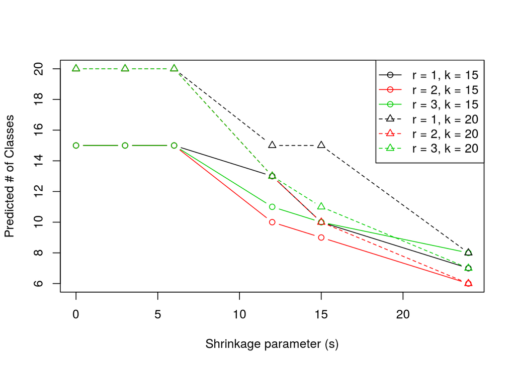

```r
plot(summary(ssc.a))
```

```r
summary(ssc.a)
```

```
##    r  k  s   method     time Predicted # of Classes
## 1  1 15  0 adaptive  448.837                     15
## 2  1 15  3 adaptive  458.728                     15
## 3  1 15  6 adaptive  460.153                     15
## 4  1 15 12 adaptive  952.794                     13
## 5  1 15 15 adaptive  743.132                     10
## 6  1 15 24 adaptive  659.919                      7
## 7  1 20  0 adaptive  561.465                     20
## 8  1 20  3 adaptive  590.554                     20
## 9  1 20  6 adaptive  593.128                     20
## 10 1 20 12 adaptive 1264.981                     15
## 11 1 20 15 adaptive  926.579                     15
## 12 1 20 24 adaptive  799.073                      8
## 13 2 15  0 adaptive 1069.382                     15
## 14 2 15  3 adaptive 1102.723                     15
```

[output cut: 59 more lines]

We want to keep the shrinkage parameter as low as possible with getting the “best”" number of clusters

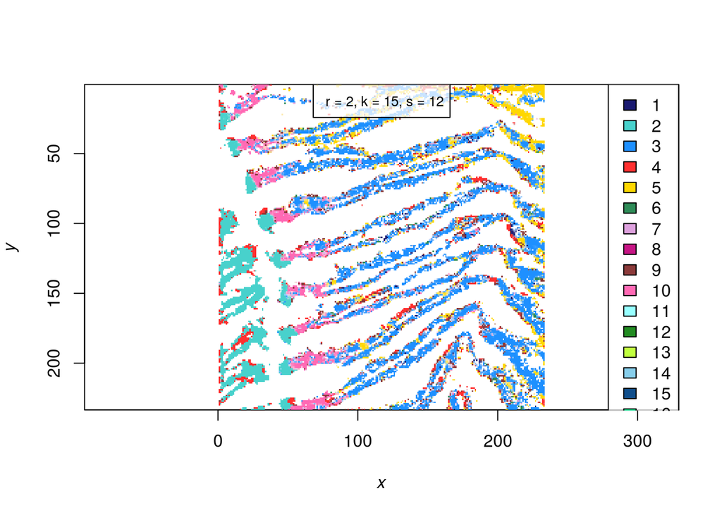

```r
mycol<-c('midnightblue', 'mediumturquoise','dodgerblue', 'firebrick1','gold','seagreen4', 'plum', 'mediumvioletred', 'indianred4', 'hotpink', 'darkslategray1', 'forestgreen','olivedrab1', 'skyblue','dodgerblue4','mediumspringgreen','coral1', 'cyan','azure','cadetblue4')

mod<-list(r=2, k=15, s=12) ## Choose a model -- 10 groups, 124 features
image(ssc.a, model=mod, col=mycol)
```

Plot each cluster group independently and choose top three ions that are part of that cluster

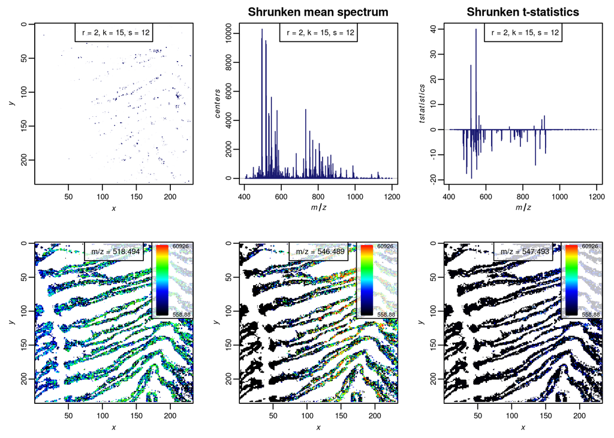

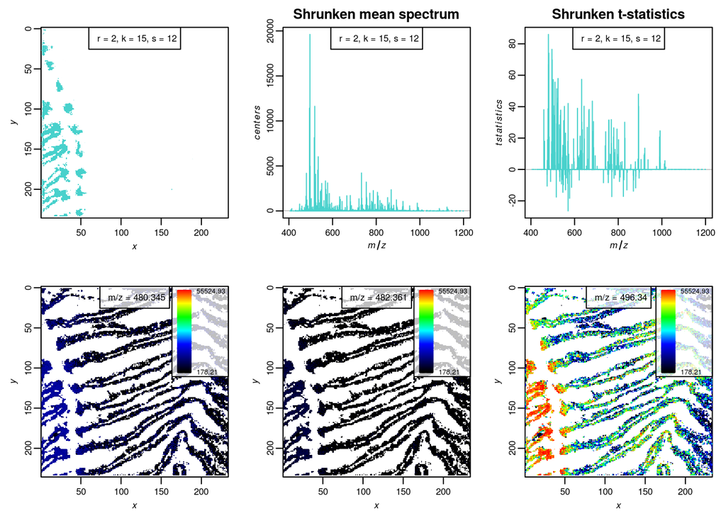

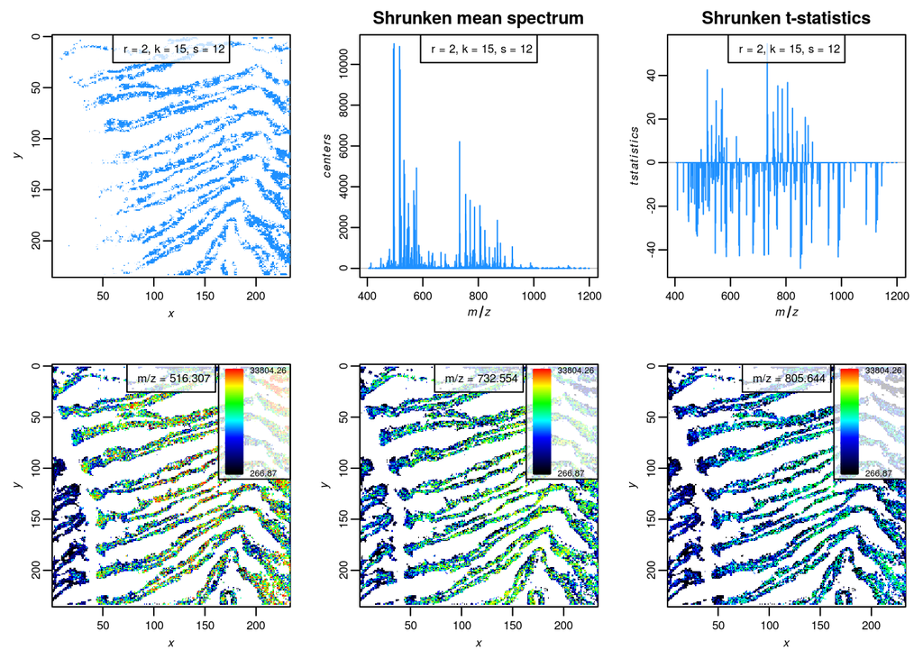

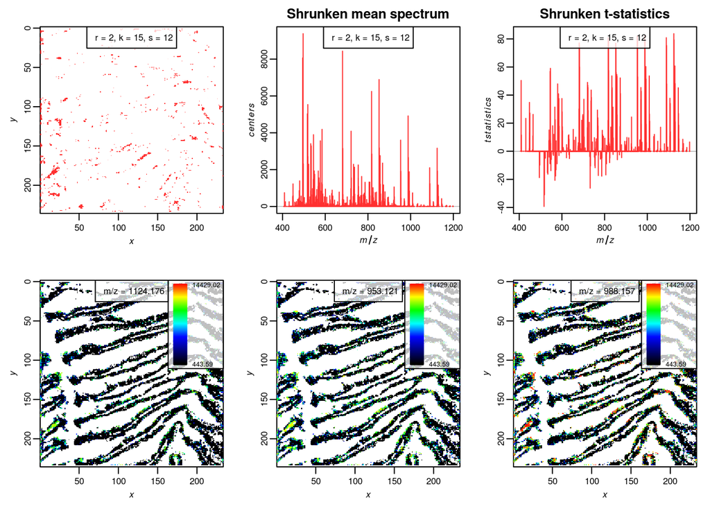

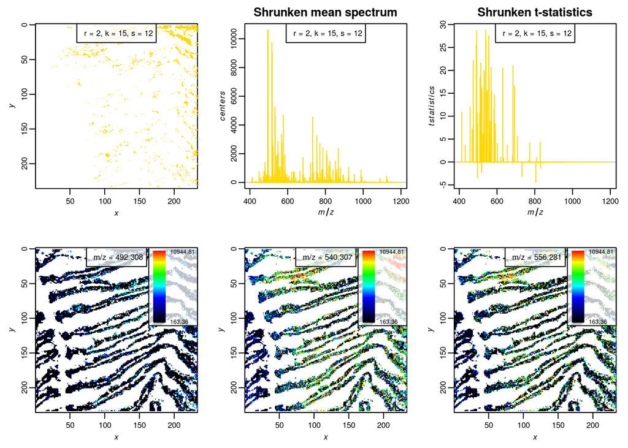

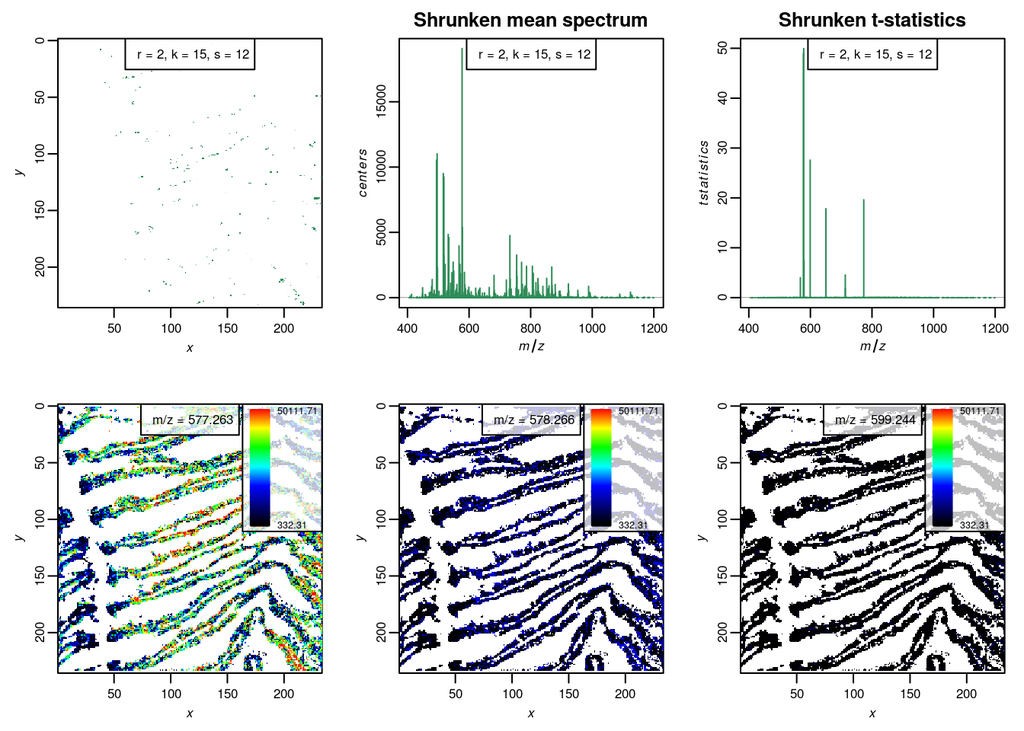

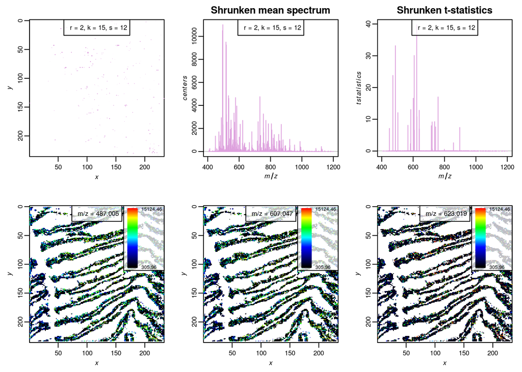

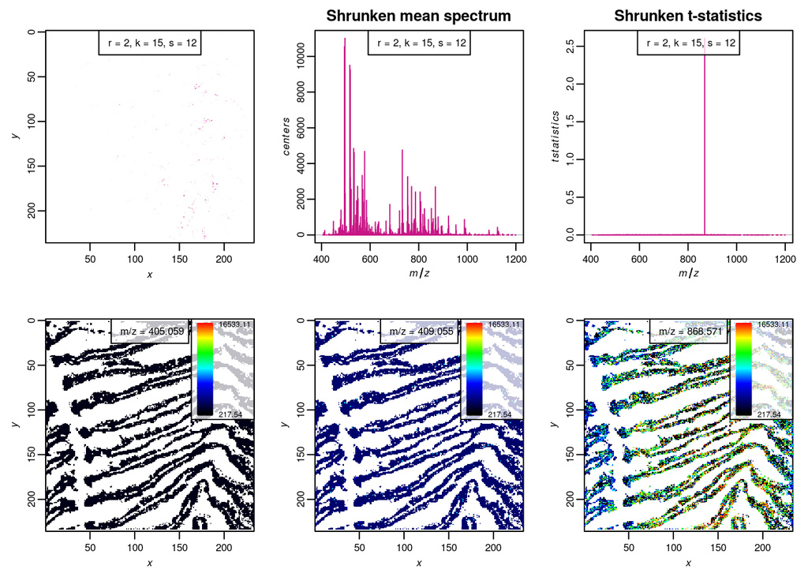

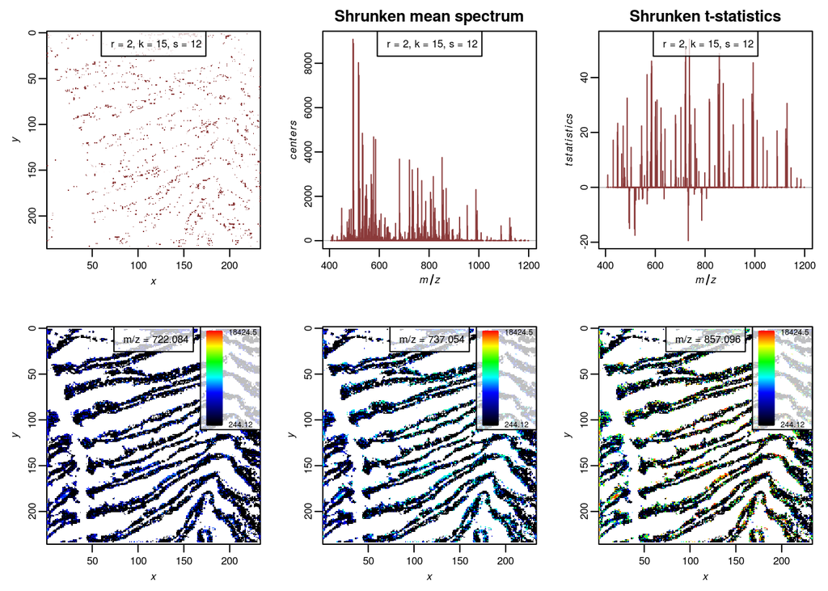

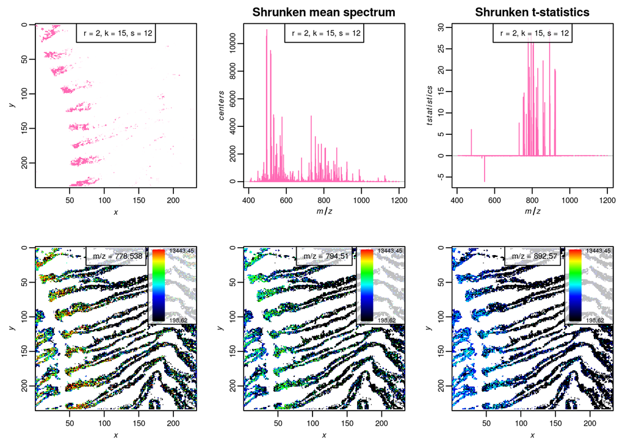

```r
#pdf('Cluster-Distribution-Plots.pdf', height=6, width=11)
 for (i in 1:10){
   summaryPlots(maldifishmz,ssc.a,model=mod,segment=i, name='', col=mycol)
 }
```

```r
#dev.off()
```

Plot percentage of FISH signals in entire dataset across clusters. This will show us which clusters the percentange of the fish groups falls

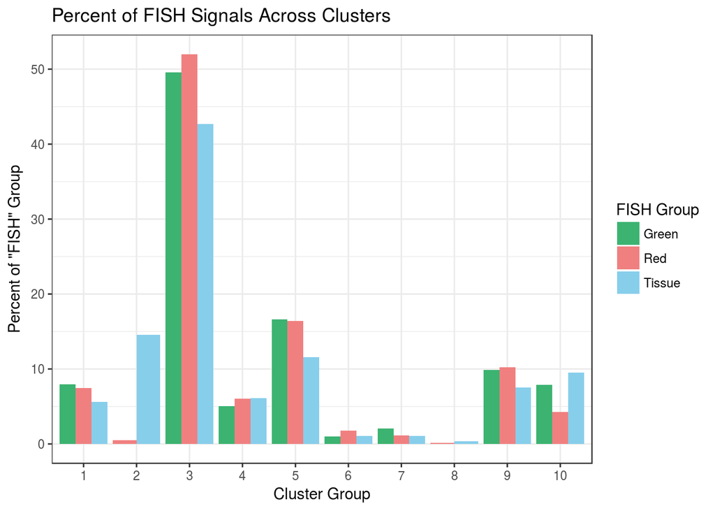

```r
## Get pixel data
pDf<-data.frame(pData(maldifishmz))
pDf$rowname<-rownames(pDf)

## Get cluster data plus coordinates
cDf<-data.frame(Cluster=ssc.a$classes$`r = 2, k = 15, s = 12`)
cDf$rowname<-rownames(cDf)

## merge cluster annotations and pixel data
df.m<-merge(pDf, cDf, by = 'rowname')

## Class membership across clusters
tab<-table(df.m$Class , df.m$Cluster)
total<-rowSums(tab)
tab<-data.frame(tab)
tab$Total<-total
tab$percent_of_group<-tab$Freq/total*100
tab<-tab[!tab$Freq==0,]

ggplot(tab, aes(x=as.factor(Var2), y=percent_of_group, fill=Var1)) + geom_bar(stat='identity', position='dodge')+ scale_fill_manual(values=c('mediumseagreen','lightcoral','skyblue')) + ggtitle('Percent of FISH Signals Across Clusters') + ylab('Percent of "FISH" Group') + xlab('Cluster Group') + guides(fill=guide_legend(title='FISH Group')) + theme_bw()
```

```r
ggsave('Cluster Membership.eps')
```

Write a datatable for the significant ions across clusters

```r
tL<-topLabels(ssc.a, model=mod, n=10000) # just set a really high number
tL.sig<-tL[which(tL$adj.p.values < 0.2),]
dim(tL.sig)
```

```
## [1] 638   9
```

```r
table(tL.sig$classes)
```

```
##
##   1   2   3   4   5   6   7   8   9  10  11  12  13  14  15  16  17  18
##   7 143  42 187  71   8  19   0 108  53   0   0   0   0   0   0   0   0
##  19  20
##   0   0
```

```r
write.csv(tL.sig, file='../Results/ssc-ions-clusterassignment.csv')
```

One thing interesting, there doens’t seem to be any ions seperating cluster 8 from the other clusters.

```r
table(ssc.a$classes$`r = 2, k = 15, s = 12`)
```

```
##
##    1    2    3    4    5    6    7    8    9   10   11   12   13   14   15
## 1253 2506 9263 1264 2615  243  230   62 1672 1812    0    0    0    0    0
```

Not that many pixels in cluster 8

### Supervised Shrunken Centriods Clustering

Creat a cross valiadation group

```r
maldifishmz$cvgroup<-cut(maldifishmz$y, breaks=5, labels = F) #based on y-location value in dataset
```

Add in cilliated edge pixels

```r
grps<-ssc.a$classes$`r = 2, k = 15, s = 12`
ciliatedgrps<-grps[which(grps==2)]
grp1<-names(ciliatedgrps)
msidata<-maldifishmz
pData(msidata)[rownames(pData(msidata)) %in% grp1,'Class']<-'CiliatedEdge'
table(msidata$Class, msidata$cvgroup)
```

```
##
##                   1    2    3    4    5
##   CiliatedEdge  160  130  749  785  682
##   Green         169  244  107   92  177
##   Red           598  637  578  583  636
##   Tissue       3140 2914 2771 2887 2881
```

```r
ssca<-spatialShrunkenCentroids(x=msidata, y=msidata$Class, s=0, r=3)
summary(ssca)
```

```
##   r k s   method   time Predicted # of Classes
## 1 3 4 0 gaussian 42.669                      4
##   Mean # of Features per Class
## 1                         2508
```

```r
ssca
```

```
## An object of class 'SpatialShrunkenCentroids'
##
##   r k s   method   time Predicted # of Classes
## 1 3 4 0 gaussian 42.669                      4
##   Mean # of Features per Class
## 1                         2508
```

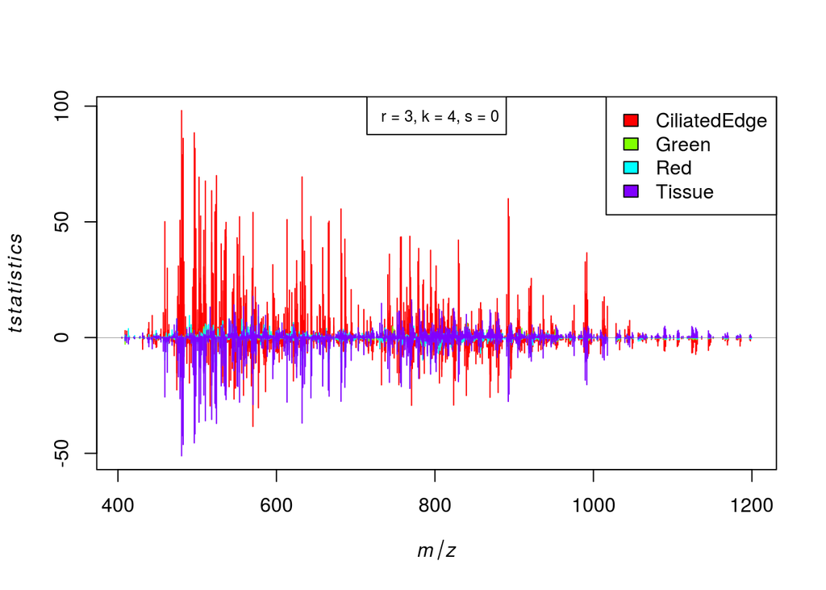

```r
plot(ssca, mode='tstatistics')
```

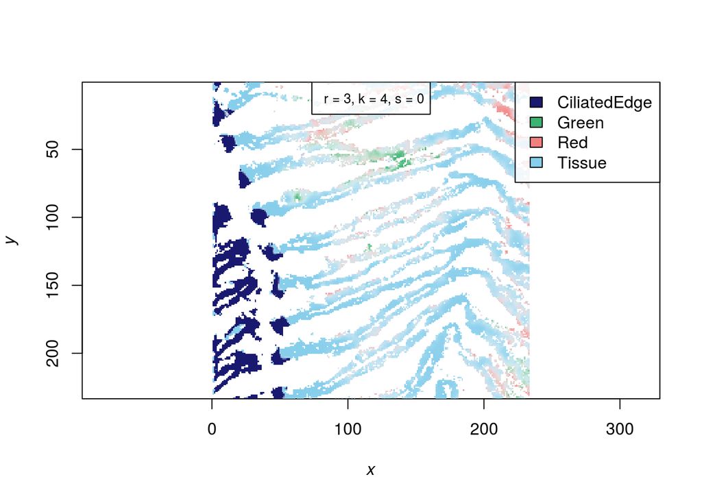

```r
image(ssca, model=list(r=3, s=0), col=c('midnightblue','mediumseagreen','lightcoral','skyblue'))
```

```r
tp<-topLabels(ssca, n=20000)
dim(tp)
```

```
## [1] 10032     9
```

```r
table(tp$classes)
```

```
##
## CiliatedEdge        Green          Red       Tissue
##         2508         2508         2508         2508
```

```r
tp.sig<-tp[which(tp$adj.p.values < 0.2),]
write.csv(tp.sig,file='../Results/ssc-classification-sigions.csv')
```